# Introduction

### Finer control of the gam function

Above we illustrated the basic use of the gam function. Here we dig in a little deeper.

The first choice we must make is on the basis used for the smooth terms. The default form the gam function is the thin plate regression spline. This basis is a good first choice, but can be computationally expensive for larger datasets.

Below we use the penalized cubic regression spline, by specifying the option `bs = "cr"`

```r
model_2 <- gam(volume ~ s(height, bs="cr") + s(diameter, bs="cr"),
               family = Gamma(link=log),
               data = trees)

summary(model_2)
```

```
##
## Family: Gamma
## Link function: log
##
## Formula:
## volume ~ s(height, bs = "cr") + s(diameter, bs = "cr")
##
## Parametric coefficients:
##             Estimate Std. Error t value Pr(>|t|)
## (Intercept)  3.27570    0.01492   219.6   <2e-16 ***
## ---
## Signif. codes:  0 '***' 0.001 '**' 0.01 '*' 0.05 '.' 0.1 ' ' 1
##
## Approximate significance of smooth terms:
##               edf Ref.df      F  p-value
## s(height)   1.000  1.000  31.32 7.07e-06 ***
## s(diameter) 2.419  3.035 219.50  < 2e-16 ***
## ---
## Signif. codes:  0 '***' 0.001 '**' 0.01 '*' 0.05 '.' 0.1 ' ' 1
##
## R-sq.(adj) =  0.973   Deviance explained = 97.8%
## GCV = 0.0080805  Scale est. = 0.006898  n = 31
```

The change in the basis function has made little difference here to our model fit. This is good news since we don’t want our model results to depend stronly on the exact choice of basis. (NOTE: If we choose a wildly different basis like with P-splines, then we will see differences)

We can also choose the dimension of our basis that represents the smoothed terms, $k$. The default value is $k=10$. This sets the maximum degrees of freedom allowed for each term. The larger this number, the more the smoothed term can “wiggle”. The actual effective degrees of freedom, for each term, will be estimated from the data.

Below we fit a model with $k = 20$ for the diameter smoothing term.

```r
model_3 <- gam(volume ~ s(height) + s(diameter, bs="cr", k = 20),
               family = Gamma(link=log),
               data = trees)

summary(model_3)
```

```
##
## Family: Gamma
## Link function: log
##
## Formula:
## volume ~ s(height) + s(diameter, bs = "cr", k = 20)
##
## Parametric coefficients:
##             Estimate Std. Error t value Pr(>|t|)
## (Intercept)  3.27570    0.01492   219.6   <2e-16 ***
## ---
## Signif. codes:  0 '***' 0.001 '**' 0.01 '*' 0.05 '.' 0.1 ' ' 1
##
## Approximate significance of smooth terms:
##               edf Ref.df      F  p-value
## s(height)   1.000  1.000  31.31 7.08e-06 ***
## s(diameter) 2.424  3.049 218.92  < 2e-16 ***
## ---
## Signif. codes:  0 '***' 0.001 '**' 0.01 '*' 0.05 '.' 0.1 ' ' 1
##
## R-sq.(adj) =  0.973   Deviance explained = 97.8%
## GCV = 0.008083  Scale est. = 0.006899  n = 31
```

Note that in the above we also didn’t change the basis for the height parameter. This is to show that we can mix bases. Here we see little difference again in the model fit.

### Smoothing over more than 1 variable

We are not restricted to models with a smooth for one predictor. Below we fit a model with a function of both height and diameter.

$$log(E(\text{volume}_i)) = f(\text{height}_i, \text{diameter}_i)\text{ where } \text{volume}_i \sim \text{Gamma}$$

```r
model_4 <- gam(volume ~ s(height, diameter, k = 25),
               family = Gamma(link=log),
               data = trees)

# model summary
summary(model_4)
```

```
##
## Family: Gamma
## Link function: log
##
## Formula:
## volume ~ s(height, diameter, k = 25)
##
## Parametric coefficients:
##             Estimate Std. Error t value Pr(>|t|)
## (Intercept)  3.27583    0.01579   207.4   <2e-16 ***
## ---
## Signif. codes:  0 '***' 0.001 '**' 0.01 '*' 0.05 '.' 0.1 ' ' 1
##
## Approximate significance of smooth terms:
##                      edf Ref.df     F p-value
## s(height,diameter) 4.791  6.487 161.5  <2e-16 ***
## ---
## Signif. codes:  0 '***' 0.001 '**' 0.01 '*' 0.05 '.' 0.1 ' ' 1
##
## R-sq.(adj) =  0.966   Deviance explained = 97.7%
## GCV = 0.0093576  Scale est. = 0.0077321  n = 31
```

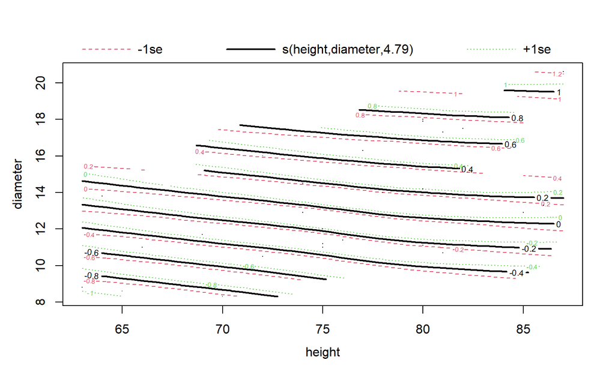

```r
# model plot
plot(model_4,too.far=0.15)
```

The default spline used in this case is the thing plate splite (option specified as `bs="tp"`). The bold contours show the estimate of the smooth while the dashed contours show the smooth plus the standard error of the smooth. Parts of the smooths that are far away from covariate values have been excluded from the plots using the too.far

Below we specify a model with tensor products as the basis, using `te` instead of `s`.

```r
model_5 <- gam(volume ~ te(height, diameter, k = 5),
               family = Gamma(link=log),
               data = trees)

# model summary
summary(model_5)
```

```
##
## Family: Gamma
## Link function: log
##
## Formula:
## volume ~ te(height, diameter, k = 5)
##
## Parametric coefficients:
##             Estimate Std. Error t value Pr(>|t|)
## (Intercept)  3.27584    0.01522   215.2   <2e-16 ***
## ---
## Signif. codes:  0 '***' 0.001 '**' 0.01 '*' 0.05 '.' 0.1 ' ' 1
##
## Approximate significance of smooth terms:
##                     edf Ref.df     F p-value
## te(height,diameter)   3      3 377.2  <2e-16 ***
## ---
## Signif. codes:  0 '***' 0.001 '**' 0.01 '*' 0.05 '.' 0.1 ' ' 1
##
## R-sq.(adj) =  0.973   Deviance explained = 97.7%
## GCV = 0.0081971  Scale est. = 0.0071821  n = 31
```

The tensor product model has 3 effective degrees of freedom. It is equivalent to the following model:

$$log(E(\text{volume}_i)) = \text{height}_i +
\text{diameter}_i + \text{height}_i:\text{diameter}_i$$

The wiggly component of the model has been penalized away.

### Models with Parametric and smoothed terms

In the 5 models we fit above, we only used smoothed terms. There is no harm or difficulty in including both parametric terms and smoothed terms.

Below we will imagine that our height variable is only measured as a categorical variable with the levels: “small”, “medium”, and “large”

```r
trees <- trees %>%
  mutate(height_class = case_when(
    floor(height/10) == 6 ~ "small",
    floor(height/10) == 7 ~ "medium",
    floor(height/10) == 8 ~ "large"
  ))

trees %>%
  count(height_class)
```

```
## # A tibble: 3 x 2
##   height_class     n
##   <chr>        <int>
## 1 large           12
## 2 medium          14
## 3 small            5
```

We now fit a model with the categorical height variable and a smoothed term for tree diameter.

```r
model_6 <- gam(volume ~ height_class + s(diameter),
               family = Gamma(link=log),
               data = trees)

# model summary
summary(model_6)
```

```
##
## Family: Gamma
## Link function: log
##
## Formula:
## volume ~ height_class + s(diameter)
##
## Parametric coefficients:
##                    Estimate Std. Error t value Pr(>|t|)
## (Intercept)         3.35722    0.03255 103.131   <2e-16 ***
## height_classmedium -0.09586    0.04528  -2.117   0.0442 *
## height_classsmall  -0.23000    0.06253  -3.678   0.0011 **
## ---
## Signif. codes:  0 '***' 0.001 '**' 0.01 '*' 0.05 '.' 0.1 ' ' 1
##
## Approximate significance of smooth terms:
##               edf Ref.df     F p-value
## s(diameter) 2.444  3.076 152.7  <2e-16 ***
## ---
## Signif. codes:  0 '***' 0.001 '**' 0.01 '*' 0.05 '.' 0.1 ' ' 1
##
## R-sq.(adj) =  0.967   Deviance explained = 96.9%
## GCV = 0.012075  Scale est. = 0.010192  n = 31
```

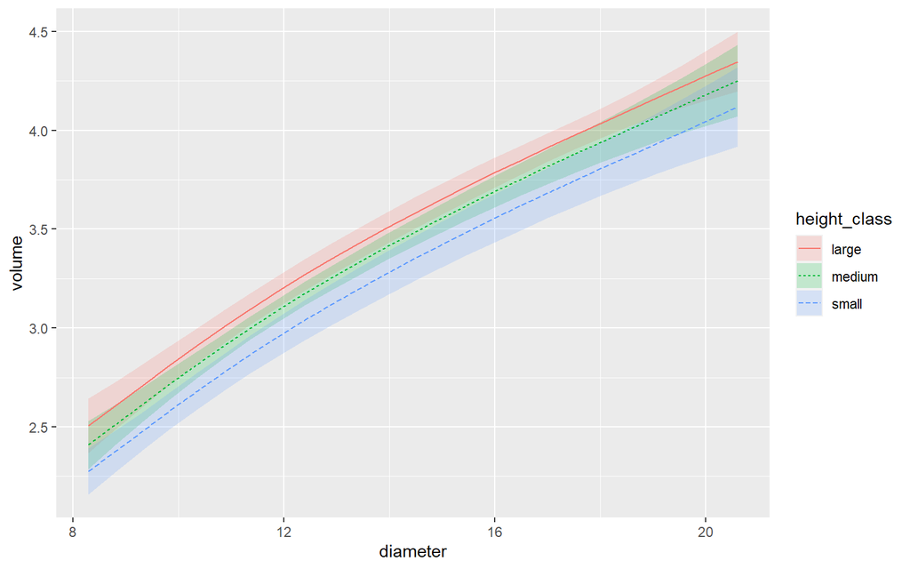

```r
plot_smooths(model_6, series = diameter, comparison = height_class)
```

In the summary we see the difference between medium and large trees and the difference between small and large trees (both statistically significant).

### More on basis functions

The smooth term in our model is a sum of some number of functions. For example, for our relationship between diameter and volume:

$$f_2(\text{diameter}_i) = \sum_{j=1}^k b_j(\text{diameter}_i)\beta_j$$

We can actually extract these basis functions from our model object with the `predict()` function. Here we extract a prediction matrix $X_p$ that maps the model parameters $\hat{\beta}$ to the predictions of the linear predictor $\hat{\eta}_p$. That is we extract the matrix $X_p$ that gives

$$\hat{\eta}_p = X_p\hat{\beta}$$

Here we work with an even simpler model with just a smoothed term for diameter.

```r
model_fit <- gam(volume ~ s(diameter),
               family = Gamma(link=log),
               data = trees)
X_p <- predict(model_fit, type = "lpmatrix")

# class of the R object
class(X_p) # its a matrix and array
```

```
## [1] "matrix" "array"
```

```r
# the dimensions
dim(X_p)
```

```
## [1] 31 10
```

```r
# the column names
colnames(X_p)
```

```
##  [1] "(Intercept)"   "s(diameter).1" "s(diameter).2" "s(diameter).3"
##  [5] "s(diameter).4" "s(diameter).5" "s(diameter).6" "s(diameter).7"
##  [9] "s(diameter).8" "s(diameter).9"
```

We can get the linear predictor by multiplying our coefficients $\hat{\beta}$ onto this matrix.

```r
# what are the coefficient names
names( coef(model_fit))
```

```
##  [1] "(Intercept)"   "s(diameter).1" "s(diameter).2" "s(diameter).3"
##  [5] "s(diameter).4" "s(diameter).5" "s(diameter).6" "s(diameter).7"
##  [9] "s(diameter).8" "s(diameter).9"
```

```r
pred <- X_p %*% coef(model_fit)
head(pred)
```

```
##       [,1]
## 1 2.336477
## 2 2.405164
## 3 2.450947
## 4 2.829134
## 5 2.870826
## 6 2.891336
```

Remember that this is just the linear predictor. To get back to the original scale we need to use the inverse link function (exp)

```r
# method 1 using the model object
predictions1 <- model_fit$family$linkinv(pred)

# method 2 using exp()
predictions2 <- exp(pred)

# are they the same
all.equal(predictions1, predictions2)
```

```
## [1] TRUE
```

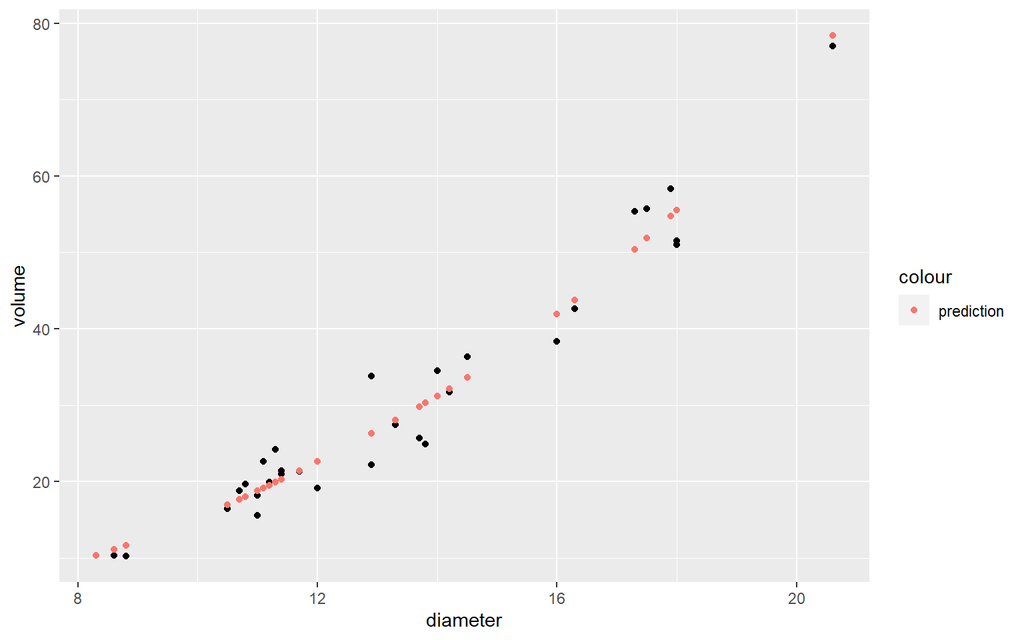

```r
# plot against the data

trees %>%
  mutate(pred = predictions1) %>%
  ggplot(aes(diameter, volume)) +
  geom_point() +
  geom_point(aes(diameter, pred, color="prediction"))
```

Why is it useful to extract the predictions this way.

The main benefit is in calculating the variance for combinations of linear predictor values.

Let $\hat{V}_\beta$ be the estimate of the parameter covariance matrix. It follows that the variance of the estimated linear predictor is then:

$$\hat{V}_{\hat{\eta}_p} = X_p\hat{V}_\beta X_p^T$$

Now, let’s say we want to look at the difference in predicted values for two different diameters, say diameter at 11 and 18

```r
new_data <- data.frame(diameter = c(11, 18))
X_p <- predict(model_fit,
               newdata = new_data,
               type = "lpmatrix")

lin_pred <- X_p%*% coef(model_fit)
```

We can model the difference as $\delta = d^T\eta_p$ where $d^t=[1,-1]$. The variance of this differnce is then given by:

$$\text{var}(\delta) = d^T\hat{V}_{\eta_p} d = d^T X_p\hat{V}_\beta X_p^Td$$

Which we can do easily with R:

```r
d <- t(c(1, -1))

# the difference
d %*% lin_pred
```

```
##           [,1]
## [1,] -1.084689
```

```r
# the variance of the difference

d %*% X_p %*% model_fit$Vp %*% t(X_p) %*%t(d)
```

```
##             [,1]
## [1,] 0.002993232
```

Note the use of `model_fit$Vp` above to get $v_\beta$.

### Model diagnostics

We can evaluate the significance of our parameters (both parametric and smoothed) using the anova function

```r
anova(model_6)
```

```
##
## Family: Gamma
## Link function: log
##
## Formula:
## volume ~ height_class + s(diameter)
##
## Parametric Terms:
##              df     F p-value
## height_class  2 6.802 0.00428
##
## Approximate significance of smooth terms:
##               edf Ref.df     F p-value
## s(diameter) 2.444  3.076 152.7  <2e-16
```

We have strong evidence that both Height and Girth matter in predicting tree volume.

We can also extract AIC from the model as we have done in the past

```r
AIC(model_6)
```

```
## [1] 155.6149
```

We can also use the gam.check function which provides diagnostic plots for our use.

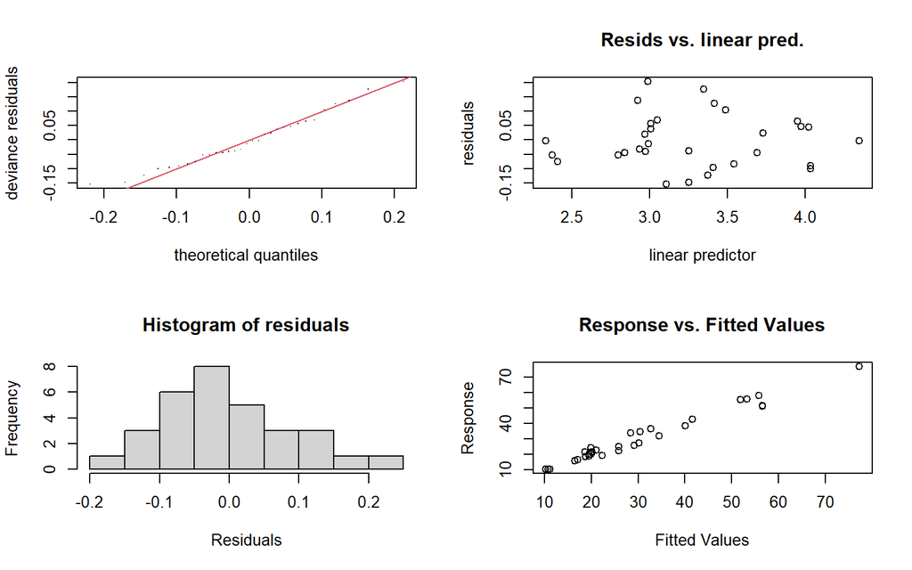

```
##
## Method: GCV   Optimizer: outer newton
## full convergence after 4 iterations.
## Gradient range [1.279532e-11,1.279532e-11]
## (score 0.01207541 & scale 0.01019232).
## Hessian positive definite, eigenvalue range [0.0004855492,0.0004855492].
## Model rank =  12 / 12
##
## Basis dimension (k) checking results. Low p-value (k-index<1) may
## indicate that k is too low, especially if edf is close to k'.
##
##               k'  edf k-index p-value
## s(diameter) 9.00 2.44    1.08    0.59
```

```r
gam.check(model_6)
```

## Understanding models (and R!) through simulation

We have stressed over and over through this course the power of simulation how the assumptions of a model could generate the data we see. We have often written our own simulation functions to simulate data for or from a model, however, there are tons of well written functions which we can use for these purposes.

Reading these functions is very helpful for:

1. Learning how models work
2. Learning how R works

I often recommend that students spend time looking at functions and trying to understand how they work. In the rest of this tutorial we will briefly present the `gamSim()` function from the mgcv package. It will be left to the students to spend more time with the function to understand its inner workings.